# HW 01

Author

Cedric Destin

## 0 - Setup

```r
options(warn=-1)
if (!require("pacman"))
  install.packages("pacman")

# use this line for installing/loading
pacman::p_load(tidyverse,
               glue,
               scales,
               openintro,
               gridExtra,
               ggrepel,
               ggmap,
               here,
               ggplot2,
               grid,
               dplyr)

devtools::install_github("tidyverse/dsbox")
```

## 1 - Road traffic accidents in Edinburgh

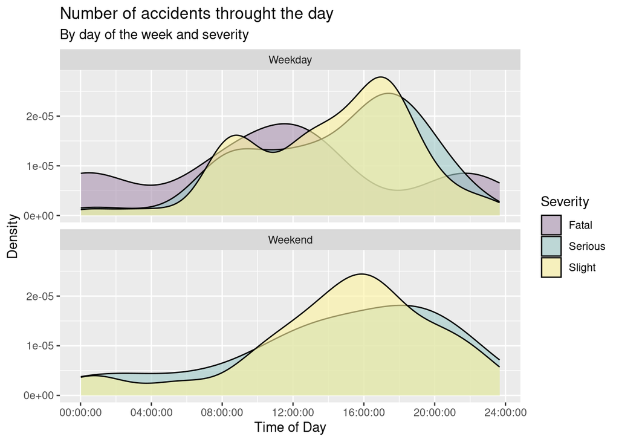

```r
accidents <- read_csv(here("data", "accidents.csv"), show_col_types = FALSE)
accidents <- accidents |>
  mutate (
    day = case_when(
      day_of_week %in% c("Monday", "Tuesday", "Wednesday", "Thursday", "Friday") ~ "Weekday",
      TRUE ~ "Weekend"
    )
  )
accidents |>
  count(id, time, severity, day) |>
  ggplot(aes(x = time, fill = severity)) +
  geom_density(alpha = 0.6) +
  facet_wrap(~ day, ncol = 1, nrow = 2) +
  scale_fill_manual("Severity", values = c("#AA93B0", "#9ECAC8", "#FEF39F")) +
  # 1 https://www.sthda.com/english/wiki/ggplot2-density-plot-quick-start-guide-r-software-and-data-visualization
  labs(title = "Number of accidents throught the day",
       subtitle = "By day of the week and severity",
       x = "Time of Day",
       y = "Density")
```

The data shows fatal accidents, Serious accidents and Slight accidents throughout the day for the Weekdays as well as the Weekends, for the city of Edinburgh, Scotland during the year of 2018.

The plot is grouped by the accident’s severity (Fatal, Serious or Slight) by using different colors then, it is grouped by the Type of weekday as two different plots, either for Weekday or Weekend.

Using this approach we can conclude the following regarding the Severity of the accidents and the type of day: Fatal accidents only occurred during weekdays, and the majority of them occur between 08:00 and 16:00. This is fascinating, one can infer that these accidents are happening while someone is commuting for work, dropping their children to school or they are commuting to school. On another note, it is interesting that the number of fatal accidents dips in the afternoon, between 16:00 and 20:00, and increases again at night between 20:00 and 23:59.

On the other hand, Serious accidents occurred in both weekdays and weekends. While they peaked during weekdays between 16:00 and 20:00, Serious accidents increase starting at 04:00 during Weekdays and stop increasing or plateau between 11:00 and 12:00 during weekdays. On the other hand, Serious accidents increase during the weekend from 00:00, and peak between 16:00 and 21:00.

Finally, Slight accidents occur approximately for the same amount during the weekend and the weekday. During the weekdays, we mainly occurred between 07:00 and 20:00, with a small dip at 10:00. Serious accidents behaved in a similar manner but the dip occured at 12:00 in the weekday. This dip is likely due to drivers being at work. At last, we see that the Slight accidents during the weekend peak peak between 12:00 an 19:00

Sources: 1 https://www.sthda.com/english/wiki/ggplot2-density-plot-quick-start-guide-r-software-and-data-visualization 2 https://chromewebstore.google.com/detail/colorzilla/bhlhnicpbhignbdhedgjhgdocnmhomnp

## 2 - NYC marathon winners

```r
nyc_marathon_data <- nyc_marathon %>% filter(!is.na(time_hrs))
```

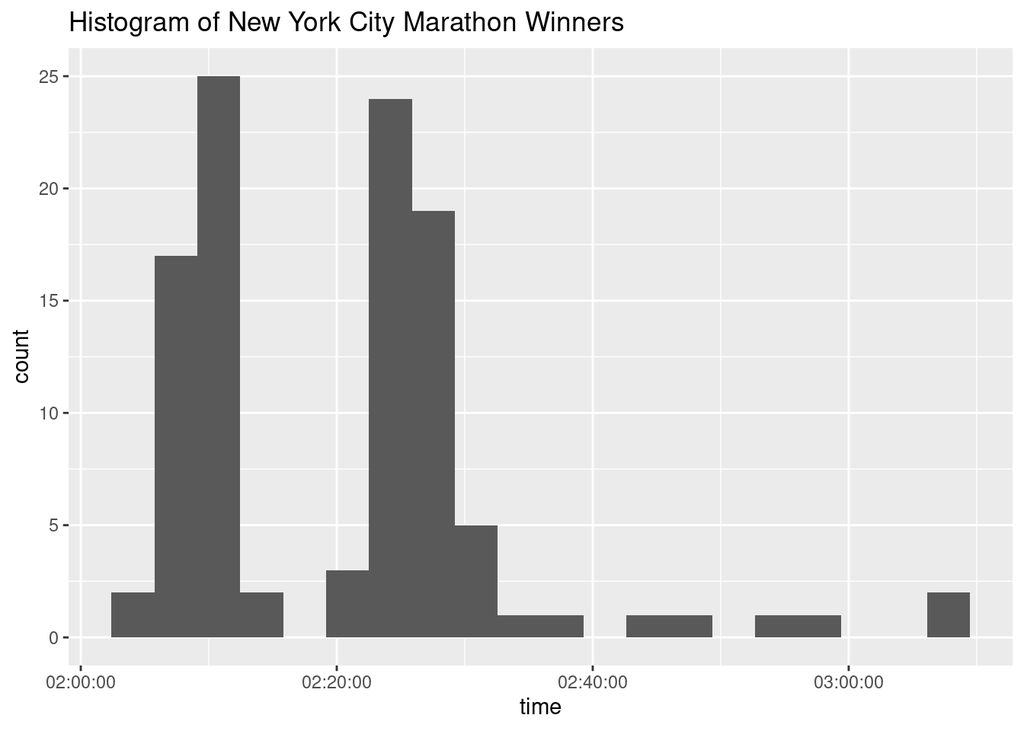

```r
ggplot(nyc_marathon_data,
       aes(x=time)) +
  labs(title = "Histogram of New York City Marathon Winners")+
  geom_histogram(bins = 20)
```

```r
# 1 https://ggplot2.tidyverse.org/reference/geom_histogram.html
```

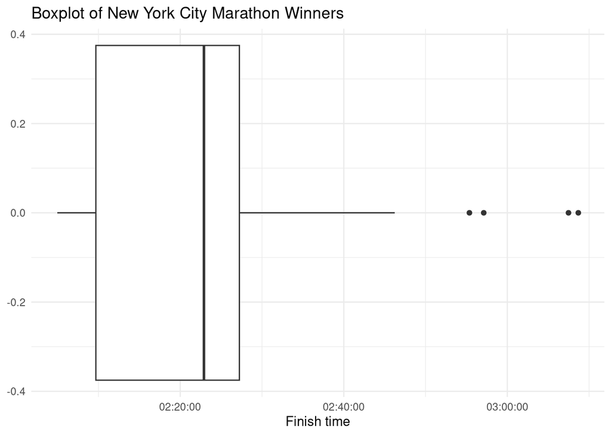

```r
ggplot(nyc_marathon_data, aes(x=time)) +
  geom_boxplot() +
  labs(
    y = NULL,
    x = "Finish time",
    title = "Boxplot of New York City Marathon Winners"
  ) +
  theme_minimal()
```

```r
# 2 https://ggplot2.tidyverse.org/reference/geom_boxplot.html
```

Looking at the histogram, we can clearly see that there are two peaks, or two clusters at times: 2:10:00 and 2:30:00, which is something that you do not see when looking at the box plot.

On the other hand, the box plot shows where the median is located by using the bar, which is something that we do not clearly see on the histogram.

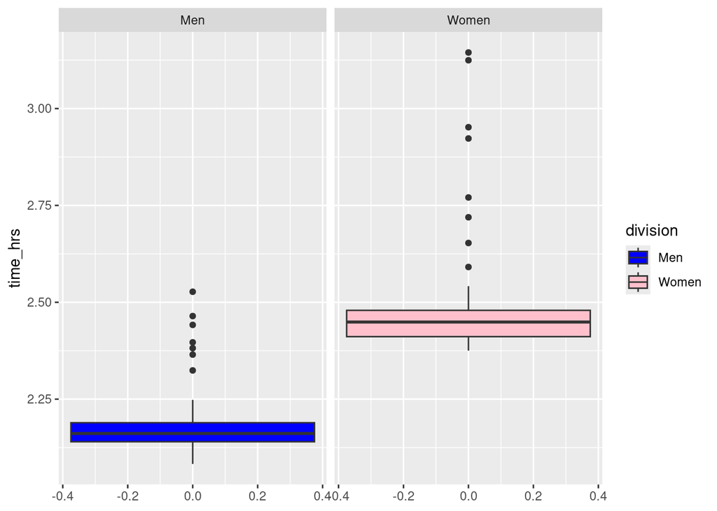

```r
ggplot(nyc_marathon_data, aes(y=time_hrs, fill = division)) +
  geom_boxplot() +
  facet_wrap(~ division, ncol = 2, nrow = 1) +
  scale_fill_manual(values = c("blue", "pink"))
```

```r
# 3 https://datavizaz.org/slides/04/04-wrangle-2.html?print-pdf=#/title-slide
```

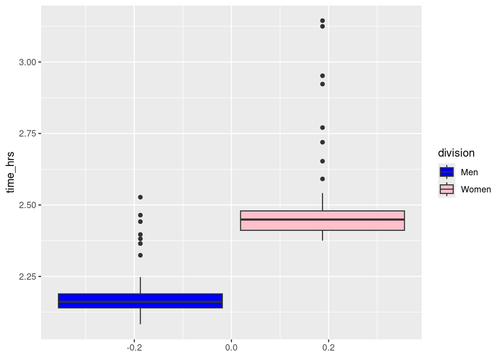

```r
ggplot(nyc_marathon_data, aes(y=time_hrs, fill = division)) +
  geom_boxplot() +
  scale_fill_manual(values = c("blue", "pink"))
```

I thought I could bring the two plots into one plot, instead of separating the plots by women vs men. This helped in the data-to-ink-ratio by removing an unnecessary axis.

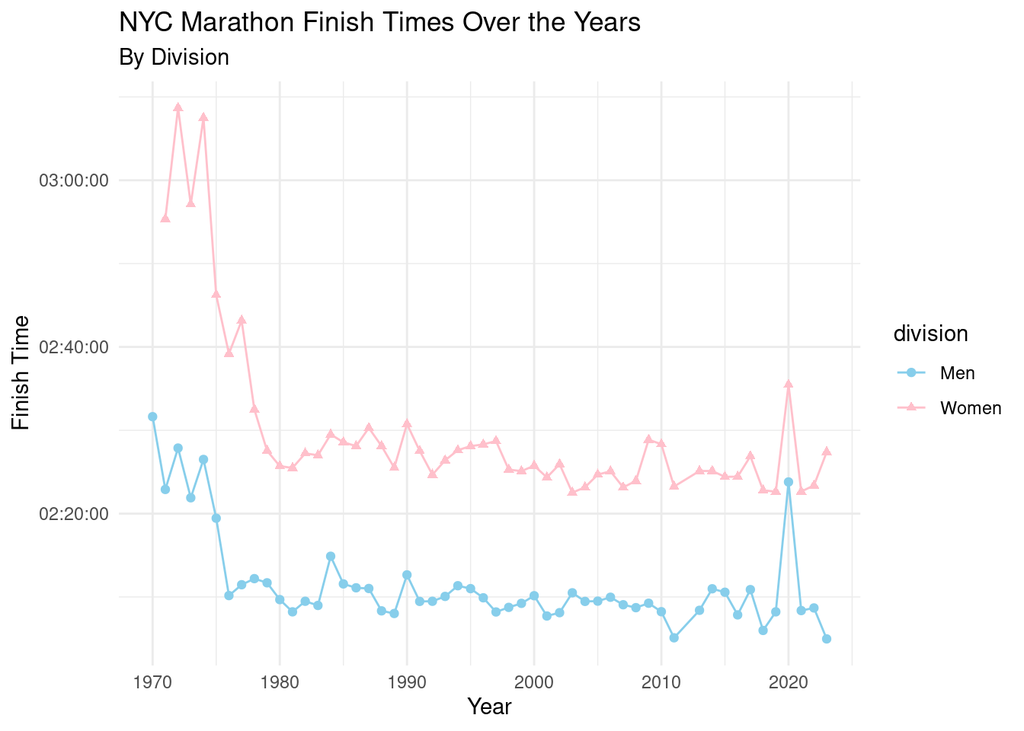

```r
ggplot(nyc_marathon_data,
       aes(x = year,
           y = time,
           group = division,
           color = division,
           shape = division)) +
  geom_point() +
  geom_line(linewidth = 0.5) +
  # https://www.sthda.com/english/wiki/ggplot2-line-plot-quick-start-guide-r-software-and-data-visualization
  labs(x = "Year",
       y = "Finish Time",
       title = "NYC Marathon Finish Times Over the Years",
       subtitle = "By Division") +
  scale_color_manual(values = c("skyblue", "pink")) +
  scale_shape_manual(values = c("circle", "triangle")) +
  theme_minimal()
```

```r
# https://ggplot2.tidyverse.org/reference/ggtheme.html
```

## 3 - US counties

```r
county_data <- county
```

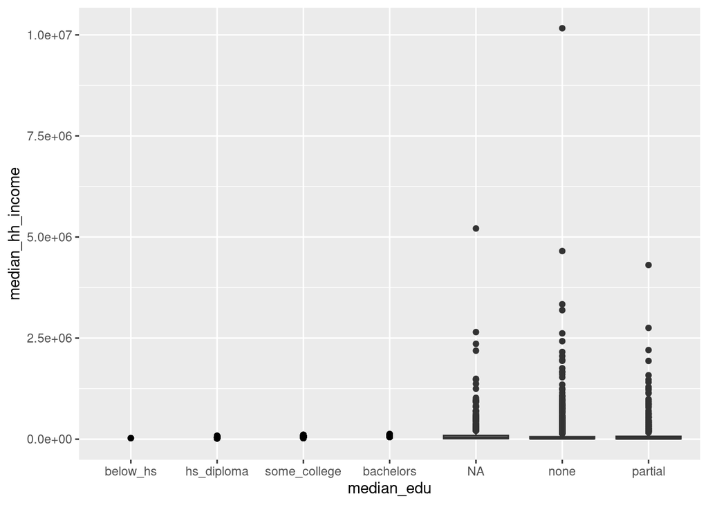

```r
options(warn=-1)
ggplot(county_data) +
  geom_point(aes(x = median_edu, y = median_hh_income)) +
  geom_boxplot(aes(x = smoking_ban, y = pop2017))
```

a. What does the following code do? Does it work? Does it make sense? Why/why not? The cell is attempting to plot a scatterplot and a box plot on the same plot. This ends up not working since the scatter-plot and the boxplot do not use the same variable for the x-axis. Hence the x-axis is labeled median_edu but it is also showing the smoking_ban information. Therefore, it does not make sense.

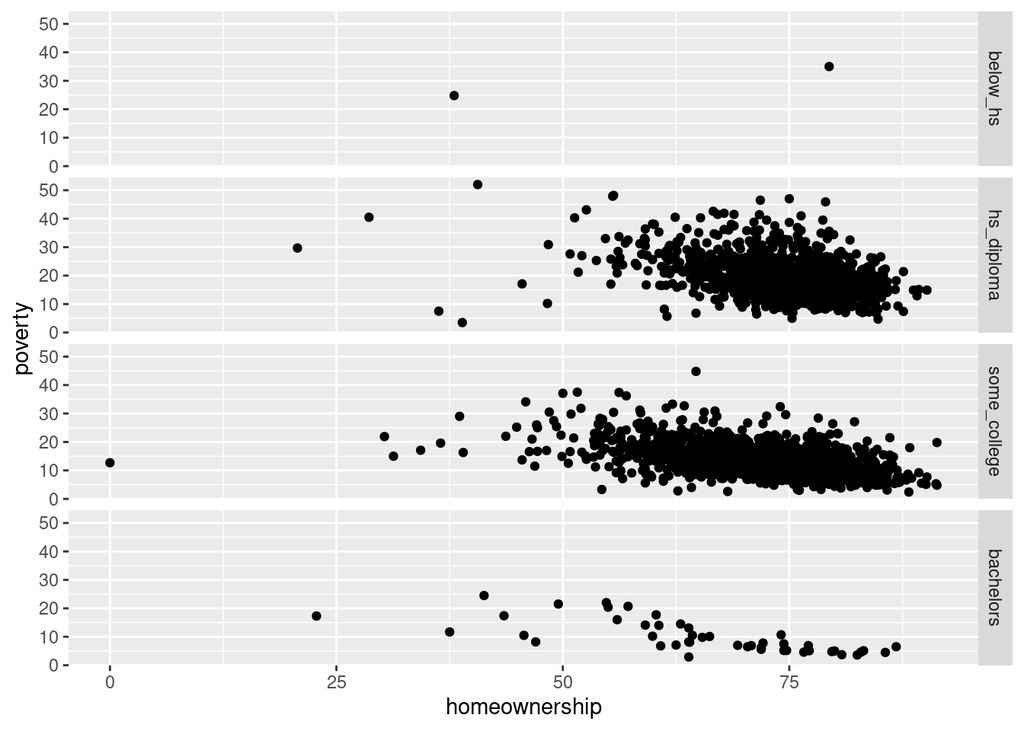

```r
ggplot(county %>% filter(!is.na(median_edu))) +
  geom_point(aes(x = homeownership, y = poverty)) +
  facet_grid(median_edu ~ .)
```

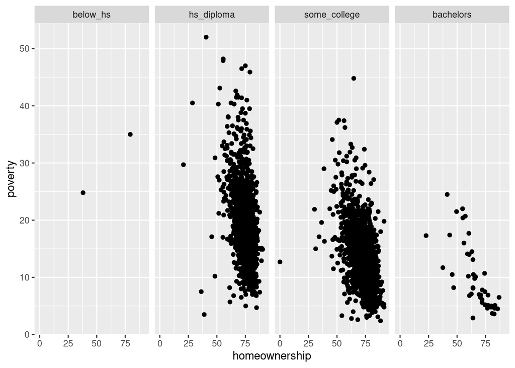

```r
ggplot(county %>% filter(!is.na(median_edu))) +
  geom_point(aes(x = homeownership, y = poverty)) +
  facet_grid(. ~ median_edu)
```

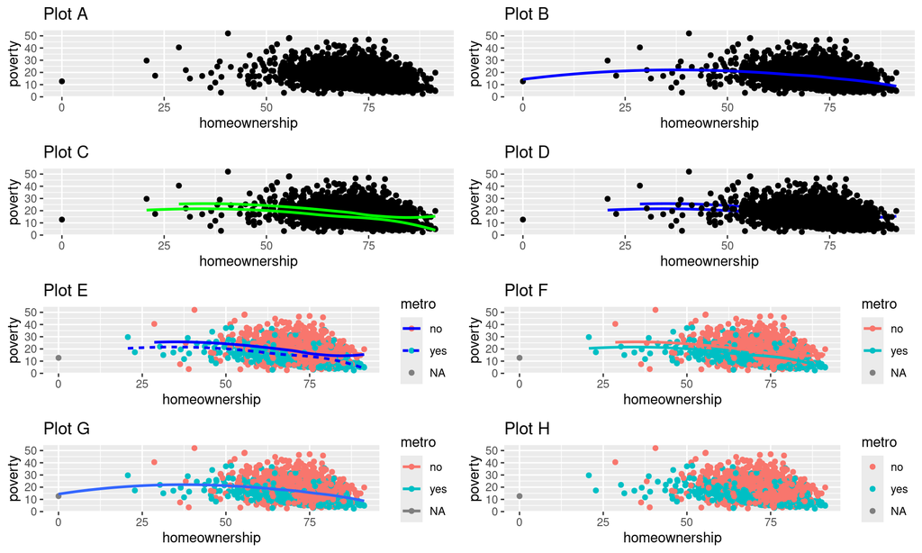

```r
plot1 <- ggplot(county %>% filter(!is.na(poverty)),
            aes(x = homeownership, y = poverty)) +
            geom_point() +
            labs(title = "Plot A")
plot2 <- ggplot(county %>% filter(!is.na(poverty)),
            aes(x = homeownership, y = poverty)) +
            geom_point() +
            geom_smooth(formula = y ~ x, method = "loess", se = FALSE, color = "blue") +
            labs(title = "Plot B")
plot3 <- ggplot(county %>% filter(!is.na(poverty)),
            aes(x = homeownership, y = poverty, group = metro)) +
            geom_point() +
            geom_smooth(formula = y ~ x, method = "loess", se = FALSE, color = "green") +
            labs(title = "Plot C")
plot4 <- ggplot(county %>% filter(!is.na(poverty)),
            aes(x = homeownership, y = poverty, group = metro)) +
            geom_smooth(formula = y ~ x, method = "loess", se = FALSE, color = "blue") +
            geom_point() +
            labs(title = "Plot D")
plot5 <- ggplot(county %>% filter(!is.na(poverty)),
            aes(x = homeownership,
                y = poverty,
                linetype = metro,
                color = metro)) +
            geom_point() +
            geom_smooth(formula = y ~ x, method = "loess", se = FALSE, color = "blue") +
            labs(title = "Plot E")
plot6 <- ggplot(county %>% filter(!is.na(poverty)),
            aes(x = homeownership,
                y = poverty,
                color = metro)) +
            geom_point() +
            geom_smooth(formula = y ~ x, method = "loess", se = FALSE) +
            labs(title = "Plot F")
plot7 <- ggplot(county %>% filter(!is.na(poverty)),
            aes(x = homeownership,
                y = poverty,
                color = metro)) +
            geom_point() +
            geom_smooth(formula = y ~ x, method = "loess", se = FALSE, aes(group = "all")) +
            labs(title = "Plot G")
plot8 <- ggplot(county %>% filter(!is.na(poverty)),
            aes(x = homeownership,
                y = poverty,
                color = metro)) +
            geom_point() +
            labs(title = "Plot H")
grid.arrange(plot1, plot2, plot3, plot4, plot5, plot6, plot7, plot8, ncol=2, nrow=4)
```

```r
# https://stackoverflow.com/questions/65985705/defining-grid-arrange-so-the-third-plot-is-in-the-middle
```

## 4 - Credit card balances

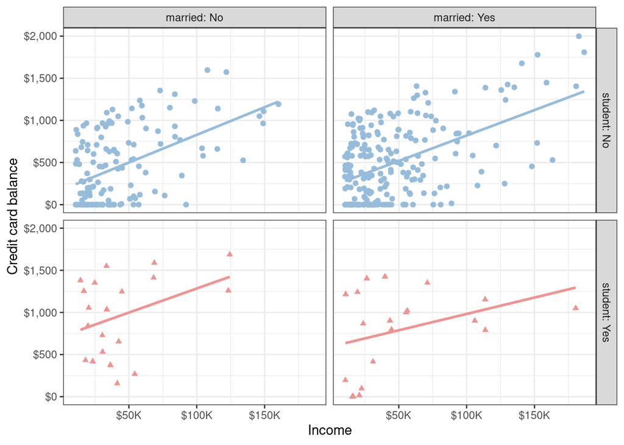

```r
credit_data <- read_csv("/cloud/project/data/credit.csv", show_col_types = FALSE)
ggplot2::theme_set(ggplot2::theme_minimal(base_size = 14))
ggplot(credit_data,
            aes(x = income, y = balance, color=student, shape = student)) +
            geom_point() +
            geom_smooth(formula = y ~ x, method = "lm", se = FALSE) +
            facet_grid(student ~ married,
                       labeller = label_both) +
            scale_shape_manual(values = c("circle", "triangle")) +
            scale_color_manual(values = c("#96BCDB", "#EE9493")) +
            scale_y_continuous(labels = label_dollar()) +
            guides(colour = "none", shape = "none") +
            scale_x_continuous(labels = function(x) paste0("$", x, "K")) +
            ylab("Credit card balance") +
            xlab("Income") +
            theme_bw()
```

```r
# https://ggplot2.tidyverse.org/reference/ggtheme.html
```

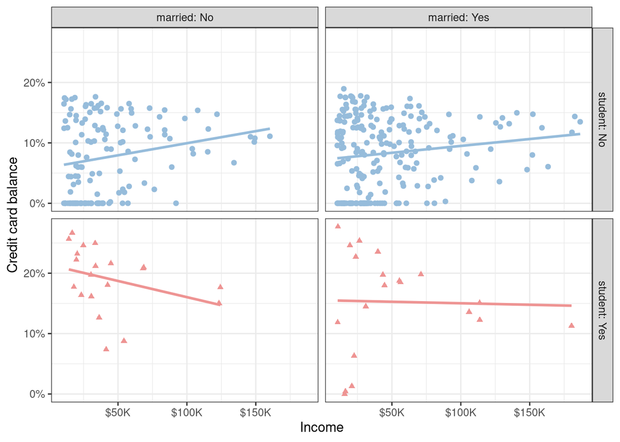

```r
credit_data <- credit_data |>
  mutate(credid_utilization = balance / limit)

ggplot(credit_data,
            aes(x = income, y = credid_utilization, color=student, shape = student)) +
            geom_point() +
            geom_smooth(method = "lm", se = FALSE, formula = y ~ x) +
            facet_grid(student ~ married,
                       labeller = label_both) +
            scale_shape_manual(values = c("circle", "triangle")) +
            scale_color_manual(values = c("#96BCDB", "#EE9493")) +
            guides(colour = "none", shape = "none") +
            scale_y_continuous(labels = label_percent()) +
            scale_x_continuous(labels = function(x) paste0("$", x, "K")) +
            ylab("Credit card balance") +
            xlab("Income") +
            theme_bw()
```

```r
# https://ggplot2.tidyverse.org/reference/ggtheme.html
```

## 5 - Napoleon’s march.

```r
napoleon_data  <- read_rds("/cloud/project/data/napoleon.rds")
```

In this problem, I answered the question with the help of http://euclid.psych.yorku.ca/www/psy6135/tutorials/Minard.html

[figure not shown]

```r
ggplot(napoleon_data$troop, aes(long, lat)) +
  geom_path(aes(size = survivors, colour = direction, group = group),
# This is the usual function for plotting the path that Napoleon and his army took.
# The colors show the direction they took and the size of the path shows
# the size of the army
            lineend = "round") +
# The end of the lines are made roung to that they connect better to each other
  scale_color_manual("Direction",
                     values = c("#E8CBAB", "#1F1A1B"),
                     labels=c("Advance", "Retreat")
# The color of the direction is changed to map the picture
) +
  geom_point(data = napoleon_data$cities) + # This simply adds the cities based on
  # the lat and lon of the city
  geom_text_repel(data = napoleon_data$cities,
                  aes(label = city),
                  size = 3, color = "red") +
  # This is a nice function used to plot the name of the city away from the lat and lot
  # markers
  coord_cartesian(xlim = c(24, 38)) +
  labs(x = NULL, y = NULL) +
  guides(size = FALSE) +
  theme_void()
```

```r
# Remove all themes
plot_troops <- last_plot()
# This is nice, it takes the last plot and saved it to a variable
```

```r
napoleon_data$temperatures <- napoleon_data$temperatures |>
  mutate(label = paste0(temp, "° ", date))
# This past the temperature symbol to the data
head(napoleon_data$temperatures$label)
```

```
[1] "0° 1812-10-18"   "0° 1812-10-24"   "-9° 1812-11-09"  "-21° 1812-11-14"
[5] "-11° 1812-11-24" "-20° 1812-11-28"
```

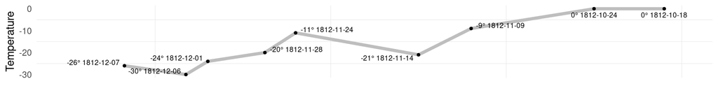

```r
ggplot(napoleon_data$temperatures,
       aes(long, temp, size = temp)) +
  geom_path(color = "grey", size = 1.5) +
  geom_point(size = 1) +
  geom_text_repel(aes(label = label), size = 2.5) +
  coord_cartesian(xlim = c(24, 38)) +
  labs(x = NULL, y = "Temperature") +
  theme_bw() +
  theme(panel.grid.major.x = element_blank(),
        panel.grid.major.y = element_blank(),
        axis.text.x = element_blank(), axis.ticks = element_blank(),
        panel.border = element_blank()
        )
```

```r
# This plots the temperature as a line, adds markers to the line and adds
# the temperature to the markers
plot_temp <- last_plot()
```

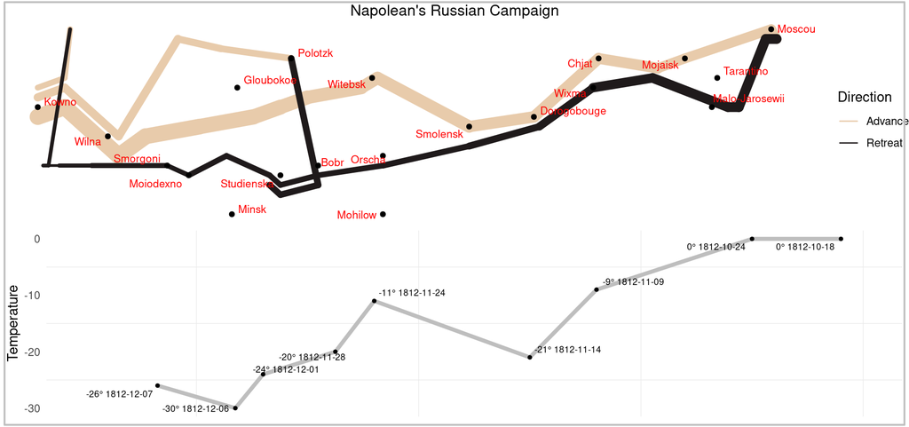

```r
grid.arrange(plot_troops, plot_temp,
          top=textGrob("Napolean's Russian Campaign"))
grid.rect(width = .99, height = .99,
          gp = gpar(lwd = 2, col = "gray", fill = NA))
```

```r
# This merges the temperature and the troop plots
```

Ultimately this was a very nice problem to solve, I wanted to add a geographical map to it, but I will not have to time to figure out why ggmap was not able to insert the map.